# 11.09.26.hw2.md

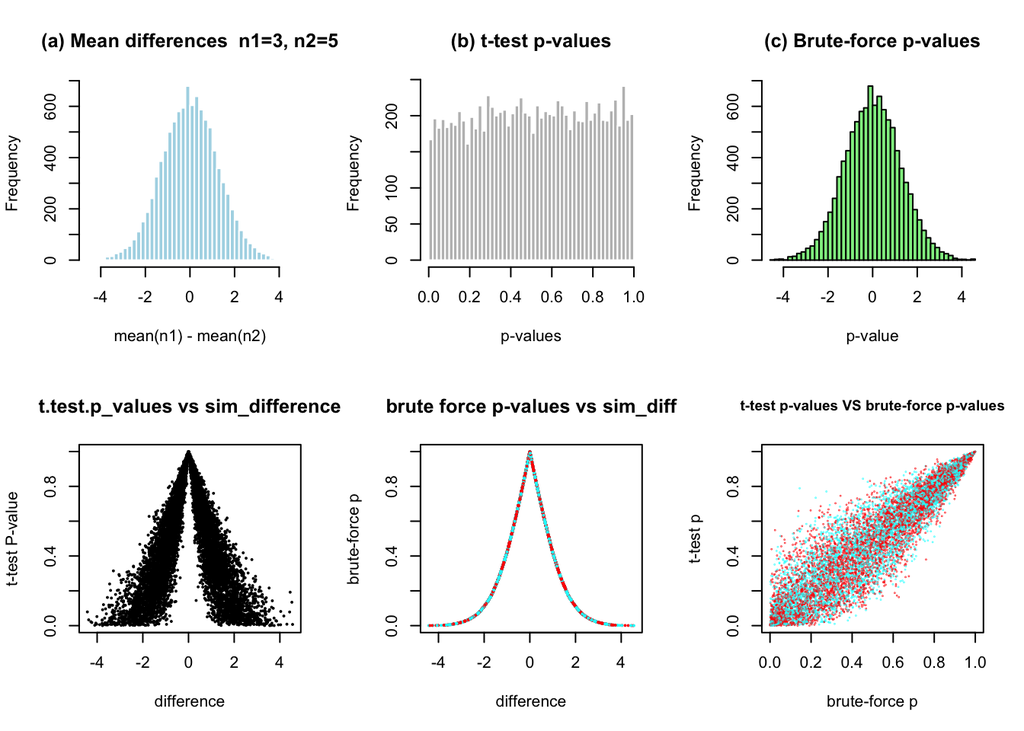

```r
n1 <-  3; n2 <- 5
small_samp <- rsmpl( n1, n2) # sample function execution
plt( small_samp) # plot function execution
```

### plots of resampling with larger sample size. (4X) (n1 <-28 ; n2 <- 36)

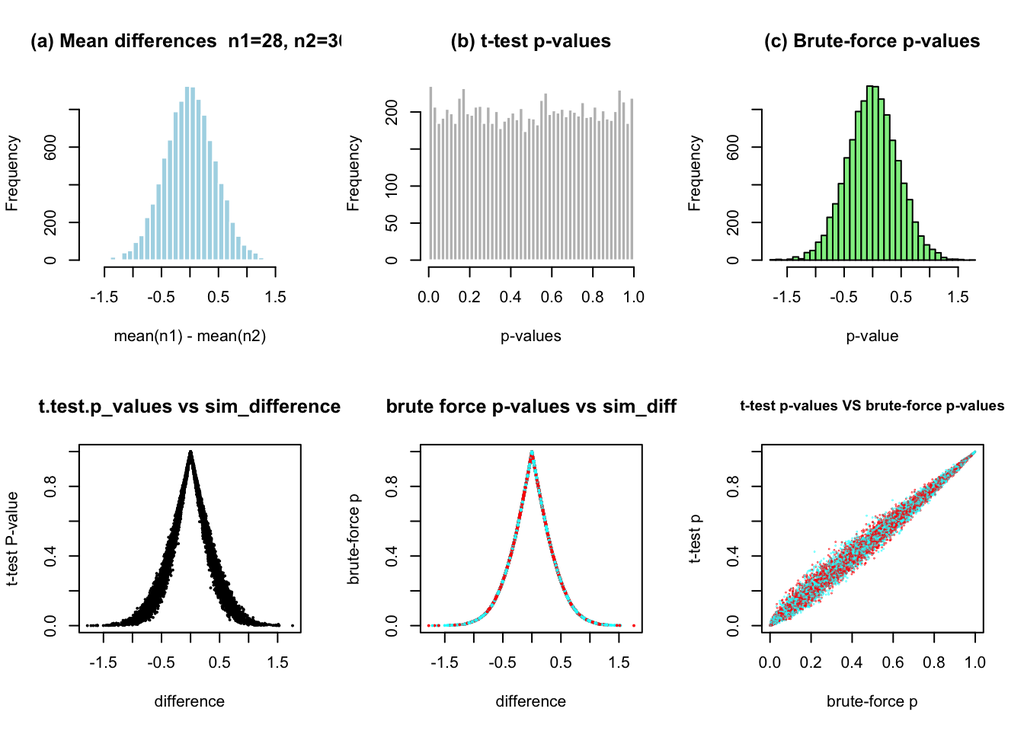

```r
n1 <-28 ; n2 <- 36

large_samp <- rsmpl( n1 , n2)

plt(large_samp)
```

### From the simulation the plot wih smaller sample size ( n= 3 and n= 5) do not appears to be significantly different from the larger sample size ( n= 28 and n= 36) in terms of the shapes of the distributions of the means differences and p-values. This mainly due to the fact that they both come from a normally distributed population ( rnorm()) and the many resampling simulation ( n.sim = 10000 ). But the highest mean differences in the smaller sample is about 4 while being ~1.5 in the larger sample sizes.

### 3.a. Using rnorm, to create two samples that result in an insignificant t-test p-value, but represent two very different processes

```r
# sampling functions

stdr_fx <- function( n){
  rnorm( n , mean = 0 , sd = 1)
}

non_stdr_fx <- function( n){
  ctr <- sample(c(-5, 5), n, replace = TRUE)
  rnorm( n , mean = ctr , sd = 1)
}
```